# Using multiple linear regression to analyse bodyfat

Pascal Bärtschi

2023-08-23

### Data Import and Preprocessing

```r
# Load data
dd <- read_delim('data/bodyfat.txt', '\t', escape_double = FALSE, trim_ws = TRUE, show_col_types = FALSE)

# Select only three columns
dd <- select(dd, bodyfat, weight, abdomen)
```

### Distribution Overview

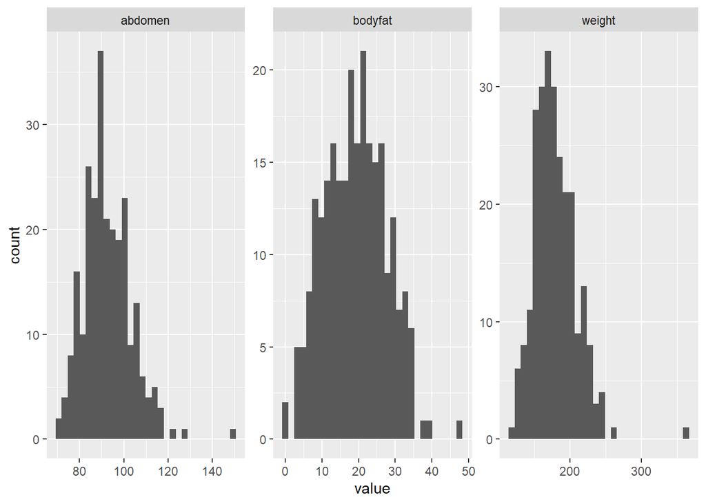

```r
# Plot histograms of each variable
dd %>%
  gather(key = "measurement", value = "value") %>%
  ggplot() +
  geom_histogram(aes(x = value)) +
  facet_wrap(~measurement, scales = "free")
```

The histograms show the distribution of the bodyfat, weight, and abdomen variables.

### Exploratory Data Analysis

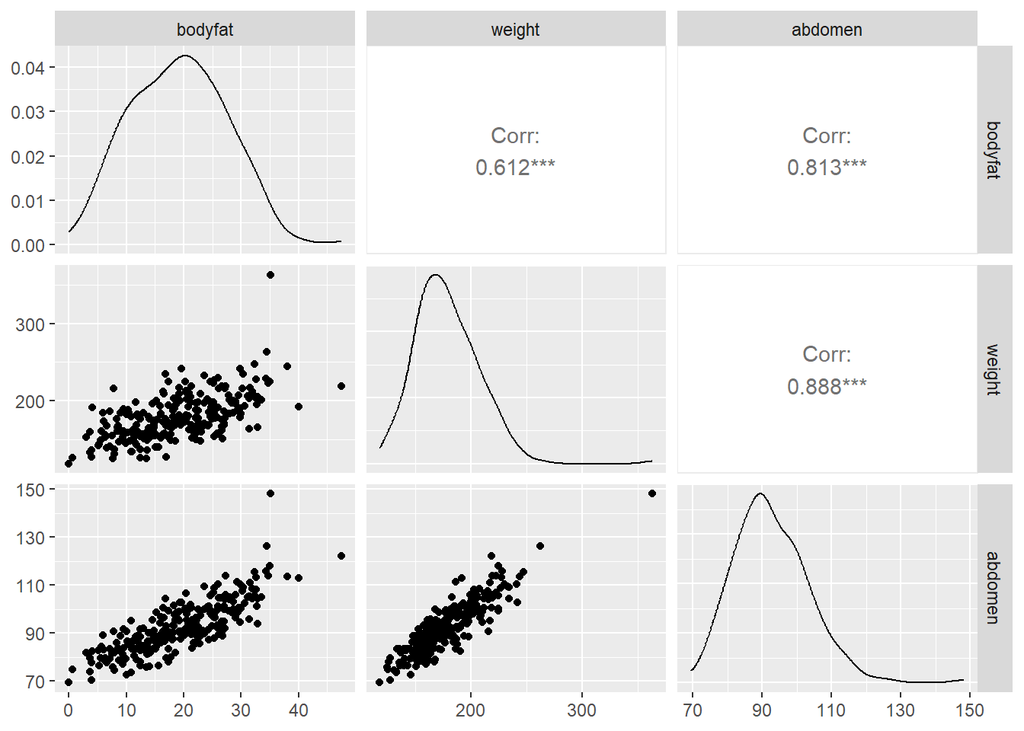

```r
# Visualize pairwise relationships
ggpairs(dd)
```

```r
# Linear Regression Model
m1 <- lm(bodyfat ~ weight + abdomen, data = dd)
```

The pairwise scatterplots provide insights into the relationships between the variables. We then build a linear regression model (m1) to predict bodyfat using weight and abdomen as explanatory variables.

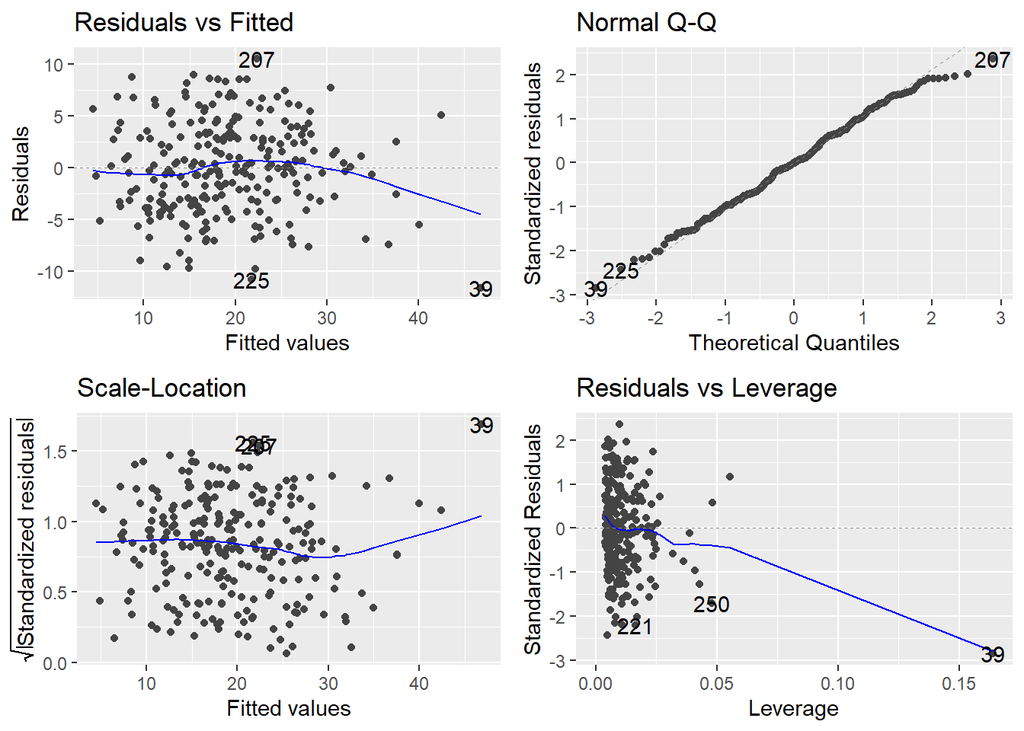

```r
# Visualize residuals
autoplot(m1)
```

```r
# Summary of the model
summary(m1)
```

```
##
## Call:
## lm(formula = bodyfat ~ weight + abdomen, data = dd)
##
## Residuals:
##      Min       1Q   Median       3Q      Max
## -11.6459  -3.2071  -0.0299   3.1664  10.5064
##
## Coefficients:
##              Estimate Std. Error t value Pr(>|t|)
## (Intercept) -45.95237    2.60501 -17.640  < 2e-16 ***
## weight       -0.14800    0.02081  -7.112 1.21e-11 ***
## abdomen       0.98950    0.05672  17.447  < 2e-16 ***
## ---
## Signif. codes:  0 '***' 0.001 '**' 0.01 '*' 0.05 '.' 0.1 ' ' 1
##
## Residual standard error: 4.456 on 249 degrees of freedom
## Multiple R-squared:  0.7188, Adjusted R-squared:  0.7165
## F-statistic: 318.2 on 2 and 249 DF,  p-value: < 2.2e-16
```

The scatterplot of residuals helps us assess the model’s assumptions. The summary provides information about the coefficients and statistical significance of the model.

```r
# Confidence intervals for coefficients
confint(m1)
```

```
##                   2.5 %      97.5 %
## (Intercept) -51.0830418 -40.8217046
## weight       -0.1889883  -0.1070178
## abdomen       0.8777997   1.1012092
```

The confidence intervals for the model coefficients provide insights into the precision of the estimates.

### Model Validation

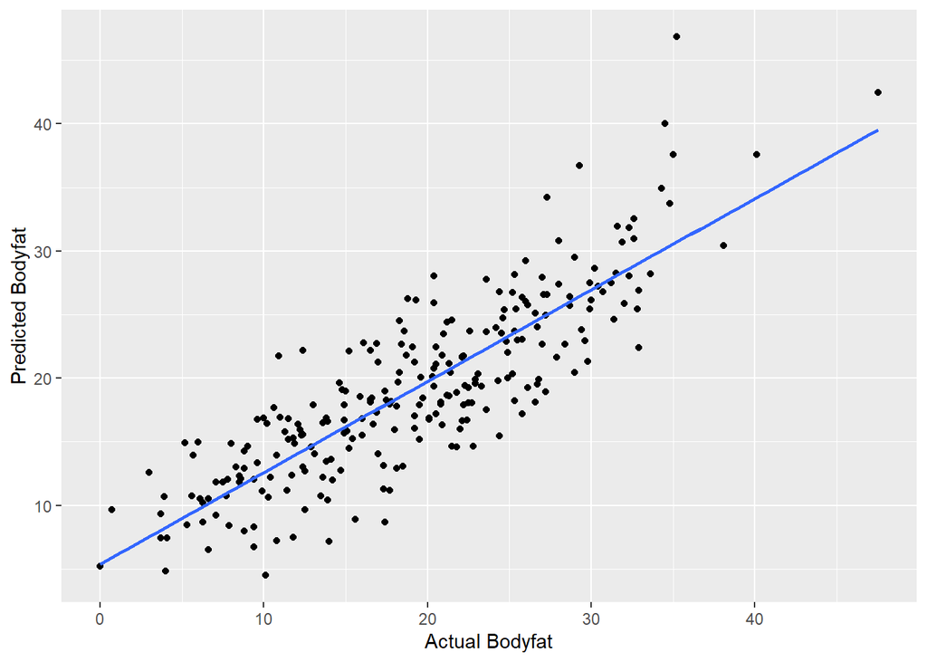

```r
# Predicted values and residuals
predicted_values <- predict(m1)
fitted_values <- fitted(m1)

# Visualize predicted vs. actual values
ggplot(data.frame(predicted = predicted_values, actual = dd$bodyfat),
       aes(x = actual, y = predicted)) +
  geom_point() +
  geom_smooth(method = "lm", se = FALSE) +
  labs(x = "Actual Bodyfat", y = "Predicted Bodyfat")
```

We validate the model by plotting predicted versus actual values. The scatterplot and regression line help us assess the model’s predictive performance.

### Model Improvement

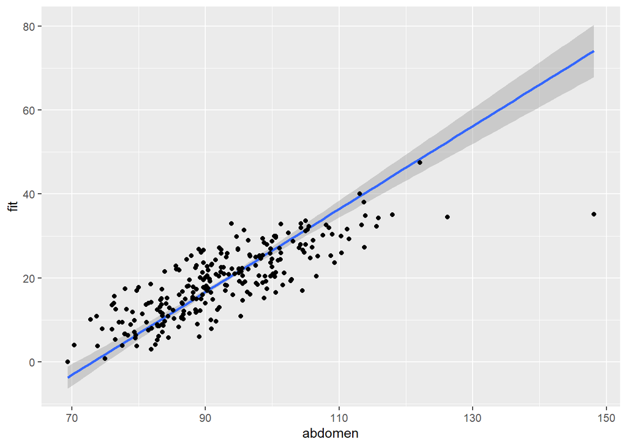

```r
# Generate new data for visualization
new_data <- expand.grid(weight = mean(dd$weight),
                        abdomen = seq(min(dd$abdomen), max(dd$abdomen), length = 100))

# Predictions with new data
predictions <- predict(m1, newdata = new_data, interval = 'confidence')
predictions_df <- cbind(new_data, predictions)

# Visualize predicted bodyfat vs. abdomen
ggplot(predictions_df) +
  geom_line(aes(x = abdomen, y = fit)) +
  geom_smooth(mapping = aes(x = abdomen, y = fit, ymin = lwr, ymax = upr),
              stat = 'identity') +
  geom_point(data = dd, aes(x = abdomen, y = bodyfat))
```

We improve the model by generating new data for visualization and predicting bodyfat values based on abdomen and weight measurements, which both seems to be accurate predictors of bodyfat

### Model Comparison and Interpretation

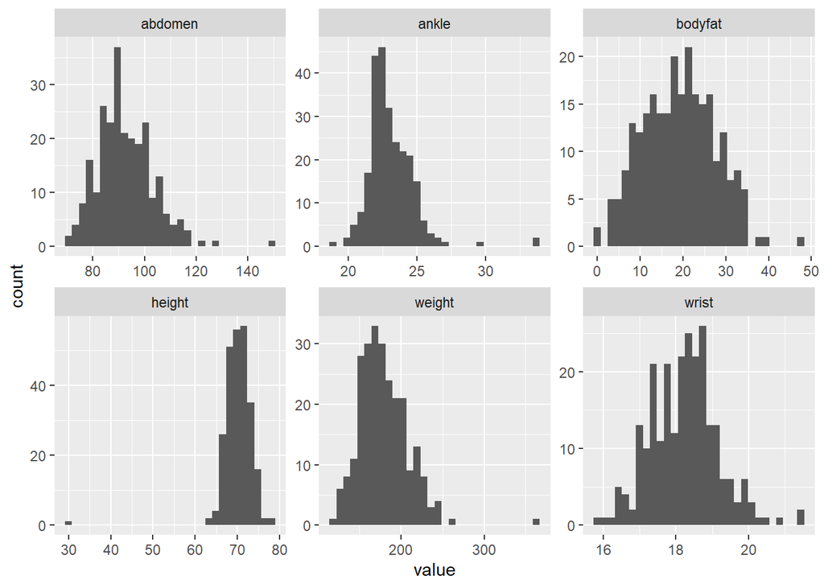

```r
# Reload to get more data
dd <- read_delim('data/bodyfat.txt', '\t', escape_double = FALSE, trim_ws = TRUE, show_col_types = FALSE)
# Select only  columns
dd <- select(dd, bodyfat, weight, abdomen, ankle, wrist, height)

dd %>%
  gather(key = "measurement", value = "value") %>%
  ggplot() +
  geom_histogram(aes(x = value)) +
  facet_wrap(~measurement, scales = "free")
```

```r
# Create models for comparison
m_both <- lm(bodyfat ~ weight + abdomen, data = dd)
m_weight <- lm(bodyfat ~ weight, data = dd)
m_abdomen <- lm(bodyfat ~ abdomen, data = dd)

# Calculate adjusted R-squared values
r2both <- summary(m_both)$adj.r.squared
r2weight <- summary(m_weight)$adj.r.squared
r2abdomen <- summary(m_abdomen)$adj.r.squared

# Calculate unique variance for each variable
r2_ua <- r2both - r2weight
r2_uw <- r2both - r2abdomen

# Calculate shared explanatory power
r2_shared <- r2both - r2_ua - r2_uw

r2 <- c(r2_ua, r2_uw, r2_shared)
names(r2) <- c("abdomen only", "weight only", "shared")
print(r2)
```

```
## abdomen only  weight only       shared
##   0.34398834   0.05622068   0.31633043
```

We compare three models (m_both, m_weight, and m_abdomen) to understand the individual and shared explanatory power of weight and abdomen on bodyfat. We see that weight exlaines the least variance in the data.

### Variable Scaling and Interpretation

```r
# Mutate variables for scaling
dd <- mutate(dd, scaled_abdomen = scale(abdomen), scaled_weight = scale(weight))

# Build model with scaled variables
m_scaled <- lm(bodyfat ~ scaled_abdomen + scaled_weight, data = dd)

# Compare scaled model with original model
summary(m_scaled)
```

```
##
## Call:
## lm(formula = bodyfat ~ scaled_abdomen + scaled_weight, data = dd)
##
## Residuals:
##      Min       1Q   Median       3Q      Max
## -11.6459  -3.2071  -0.0299   3.1664  10.5064
##
## Coefficients:
##                Estimate Std. Error t value Pr(>|t|)
## (Intercept)     19.1508     0.2807  68.231  < 2e-16 ***
## scaled_abdomen  10.6699     0.6116  17.447  < 2e-16 ***
## scaled_weight   -4.3497     0.6116  -7.112 1.21e-11 ***
## ---
## Signif. codes:  0 '***' 0.001 '**' 0.01 '*' 0.05 '.' 0.1 ' ' 1
##
## Residual standard error: 4.456 on 249 degrees of freedom
## Multiple R-squared:  0.7188, Adjusted R-squared:  0.7165
## F-statistic: 318.2 on 2 and 249 DF,  p-value: < 2.2e-16
```

```r
summary(m_both)
```

```
##
## Call:
## lm(formula = bodyfat ~ weight + abdomen, data = dd)
##
## Residuals:
##      Min       1Q   Median       3Q      Max
## -11.6459  -3.2071  -0.0299   3.1664  10.5064
##
## Coefficients:
##              Estimate Std. Error t value Pr(>|t|)
## (Intercept) -45.95237    2.60501 -17.640  < 2e-16 ***
## weight       -0.14800    0.02081  -7.112 1.21e-11 ***
## abdomen       0.98950    0.05672  17.447  < 2e-16 ***
## ---
## Signif. codes:  0 '***' 0.001 '**' 0.01 '*' 0.05 '.' 0.1 ' ' 1
##
## Residual standard error: 4.456 on 249 degrees of freedom
## Multiple R-squared:  0.7188, Adjusted R-squared:  0.7165
## F-statistic: 318.2 on 2 and 249 DF,  p-value: < 2.2e-16
```

We standardize variables to prevent misinterpretations due to different scales and build a model (m_scaled) using scaled variables.

### Broom Package for Model Summaries

```r
# Use broom package for model summaries
library(broom)
tidy(m_scaled)
```

```
## # A tibble: 3 x 5
##   term           estimate std.error statistic   p.value
##   <chr>             <dbl>     <dbl>     <dbl>     <dbl>
## 1 (Intercept)       19.2      0.281     68.2  3.66e-163
## 2 scaled_abdomen    10.7      0.612     17.4  4.49e- 45
## 3 scaled_weight     -4.35     0.612     -7.11 1.21e- 11
```

```r
augment(m_scaled)
```

```
## # A tibble: 252 x 9
##    bodyfat scaled_abdomen[,1] scaled_weight[,1] .fitted .resid    .hat .sigma
##      <dbl>              <dbl>             <dbl>   <dbl>  <dbl>   <dbl>  <dbl>
##  1    12.3             -0.682           -0.840    15.5  -3.22  0.00685   4.46
##  2     6.1             -0.886           -0.193    10.5  -4.43  0.0137    4.46
##  3    25.3             -0.432           -0.848    18.2   7.07  0.00878   4.44
##  4    10.4             -0.571            0.198    12.2  -1.80  0.0146    4.46
##  5    28.7              0.690            0.181    25.7   2.97  0.00938   4.46
##  6    20.9              0.171            1.07     16.3   4.56  0.0198    4.45
##  7    19.2             -0.172            0.0706   17.0   2.19  0.00503   4.46
##  8    12.4             -0.376           -0.0995   15.6  -3.17  0.00557   4.46
##  9     4.1             -0.933            0.411     7.41 -3.31  0.0364    4.46
## 10    11.7             -0.367            0.658    12.4  -0.676 0.0227    4.46
## # i 242 more rows
## # i 2 more variables: .cooksd <dbl>, .std.resid <dbl>
```

```r
glance(m_scaled)
```

```
## # A tibble: 1 x 12
##   r.squared adj.r.squared sigma statistic  p.value    df logLik   AIC   BIC
##       <dbl>         <dbl> <dbl>     <dbl>    <dbl> <dbl>  <dbl> <dbl> <dbl>
## 1     0.719         0.717  4.46      318. 2.53e-69     2  -733. 1473. 1487.
## # i 3 more variables: deviance <dbl>, df.residual <int>, nobs <int>
```

The broom package provides convenient functions (tidy, augment, glance) to extract useful information from the model.

### Visualizing Model Coefficients

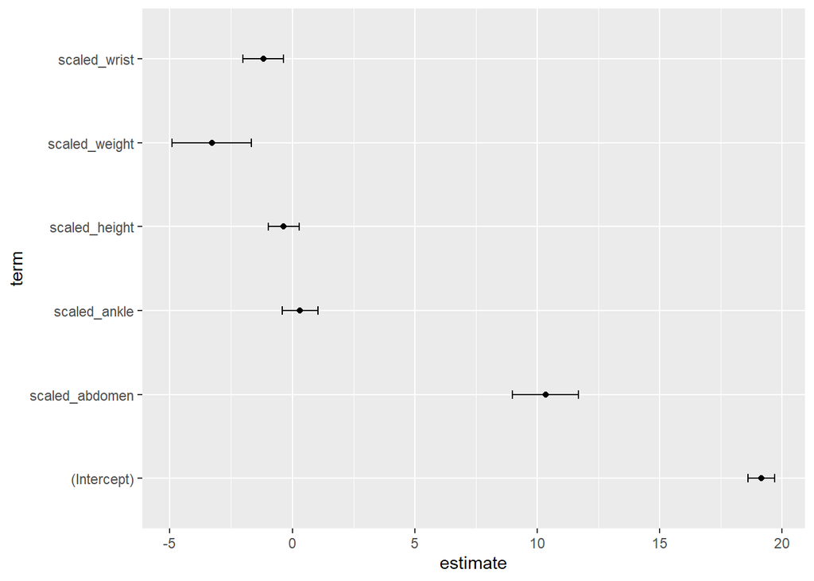

```r
# Mutate additional variables for scaling
dd <- mutate(dd, scaled_wrist = scale(wrist), scaled_ankle = scale(ankle),
             scaled_height = scale(height))

# Build model with additional scaled variables
m <- lm(bodyfat ~ scaled_height + scaled_ankle + scaled_wrist + scaled_abdomen + scaled_weight, data = dd)

# Extract coefficient information
td <- tidy(m, conf.int = TRUE)

# Visualize coefficients
ggplot(td, aes(estimate, term)) +
  geom_point() +
  geom_errorbar(mapping = aes(xmin = conf.low, xmax = conf.high), width = 0.1 )
```

We visualize the coefficients of the model using scatterplots with error bars.

### Conclusion

In this analysis, we performed exploratory data analysis, built linear regression models, improved model fit, and compared different models to understand the relationship between bodyfat, weight, and abdomen. We explored various aspects of regression analysis and model interpretation to gain insights into the variables’ influence on body fat percentages.